# Multivariate Data Analysis Assignment #5

2018170865 산업경영공학부 박재현

2021. 5. 21.

```r
suppressMessages({
  library(nnet)
  library(ggplot2)
  library(psych)
  library(caret)
  library(tree)
  library(party)
  library(ROCR)
  library(glmnet)
  library(GA)
  library(pROC)
  library(rpart)
  library(VGAM)
})
perf_eval_multi <- function(cm){

  # Simple Accuracy
  ACC = sum(diag(cm))/sum(cm)

  # Balanced Correction Rate
  BCR = 1
  for (i in 1:dim(cm)[1]){
    BCR = BCR*(cm[i,i]/sum(cm[i,]))
  }

  BCR = BCR^(1/dim(cm)[1])

  return(c(ACC, BCR))
}
```

```r
data_values <- read.csv("train_values.csv", header = TRUE, stringsAsFactors=TRUE)
data_labels <- read.csv("train_labels.csv", header = TRUE, stringsAsFactors=TRUE)

data <- data.frame(data_values, data_labels)
data <- data[,c(-1,-40)]
```

### [Q1] 입력 변수의 속성이 numeric이 아닌 변수들을 모두 확인하고, 각 변수들의 요인 값들에 대한 Bar chart를 도시하시오.

입력 변수의 속성이 numeric이 아닌 변수들은 총 8개로 다음과 같다.  
1. land_surface_condition : n, o, t  
2. foundation_type : h, i, r, u, w  
3. roof_type : n, q, x  
4. ground_floor_type : f, m, v, x, z  
5. other_floor_type : j, q, s, x  
6. position : j, o, s, t  
7. plan_configuration : a, c, d, f, m, n, o, q, s, u  
8. legal_ownership_status : a, r, v, w

한편, 입력 변수의 속성은 numeric이지만 범주형 변수에 속하는 이진 변수들은 총 22개로 다음과 같다.  
1. has_superstructure_adobe_mud  
2. has_superstructure_mud_mortar_stone  
3. has_superstructure_stone_flag  
4. has_superstructure_cement_mortar_stone  
5. has_superstructure_mud_mortar_brick  
6. has_superstructure_cement_mortar_brick  
7. has_superstructure_timber  
8. has_superstructure_bamboo  
9. has_superstructure_rc_non_engineered  
10. has_superstructure_rc_engineered  
11. has_superstructure_other  
12. has_secondary_use  
13. has_secondary_use_agriculture  
14. has_secondary_use_hotel  
15. has_secondary_use_rental  
16. has_secondary_use_institution  
17. has_secondary_use_school  
18. has_secondary_use_industry  
19. has_secondary_use_health_post  
20. has_secondary_use_gov_office  
21. has_secondary_use_use_police  
22. has_secondary_use_other

```r
q1 <- sapply(data, function(x) is.factor(x))
q1[q1==TRUE]
```

```
## land_surface_condition        foundation_type              roof_type
##                   TRUE                   TRUE                   TRUE
##      ground_floor_type       other_floor_type               position
##                   TRUE                   TRUE                   TRUE
##     plan_configuration legal_ownership_status
##                   TRUE                   TRUE
```

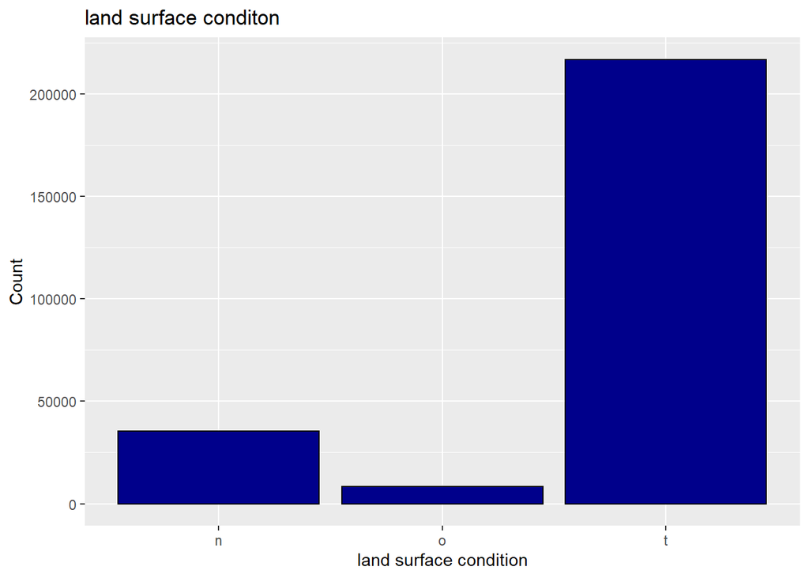

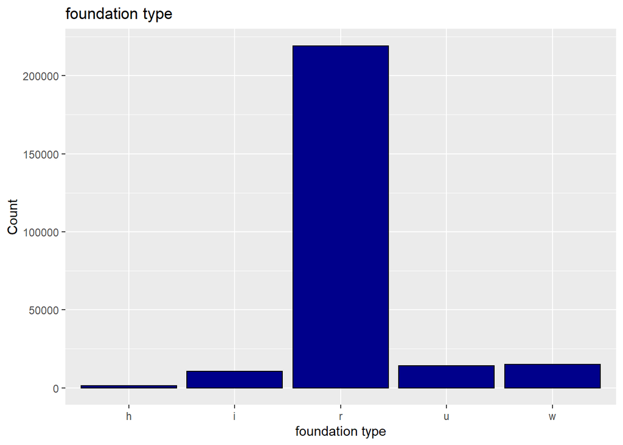

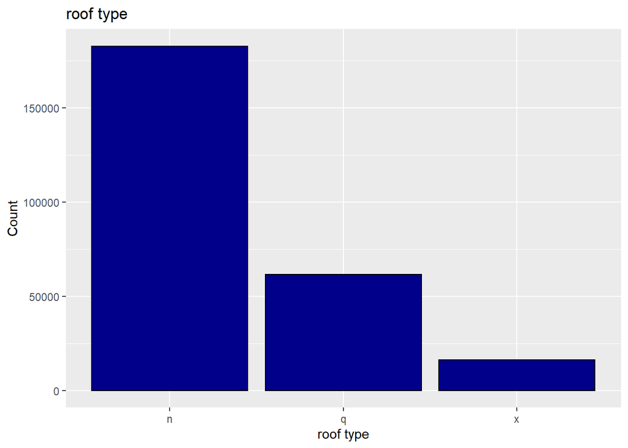

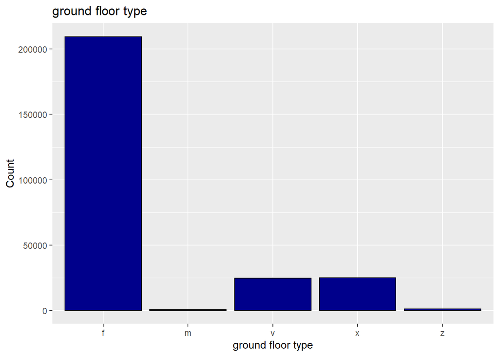

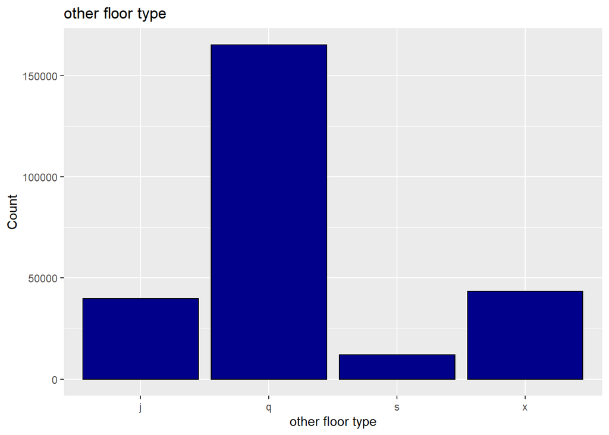

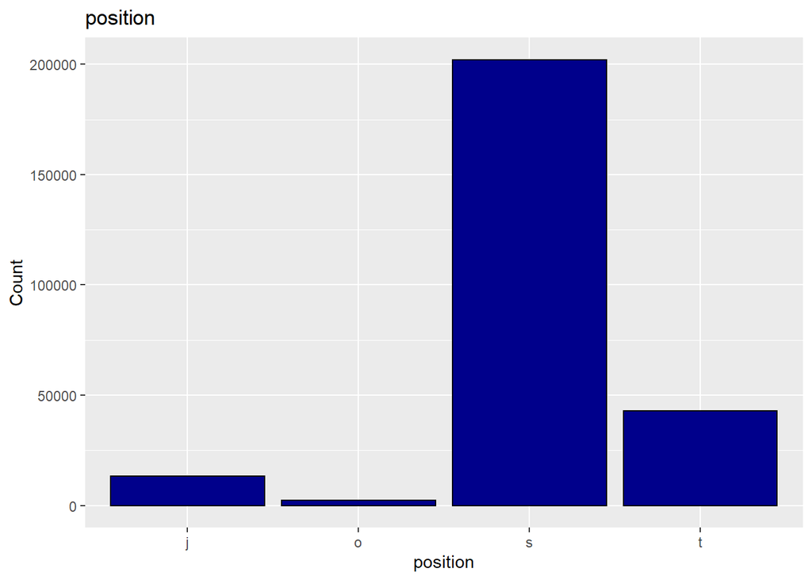

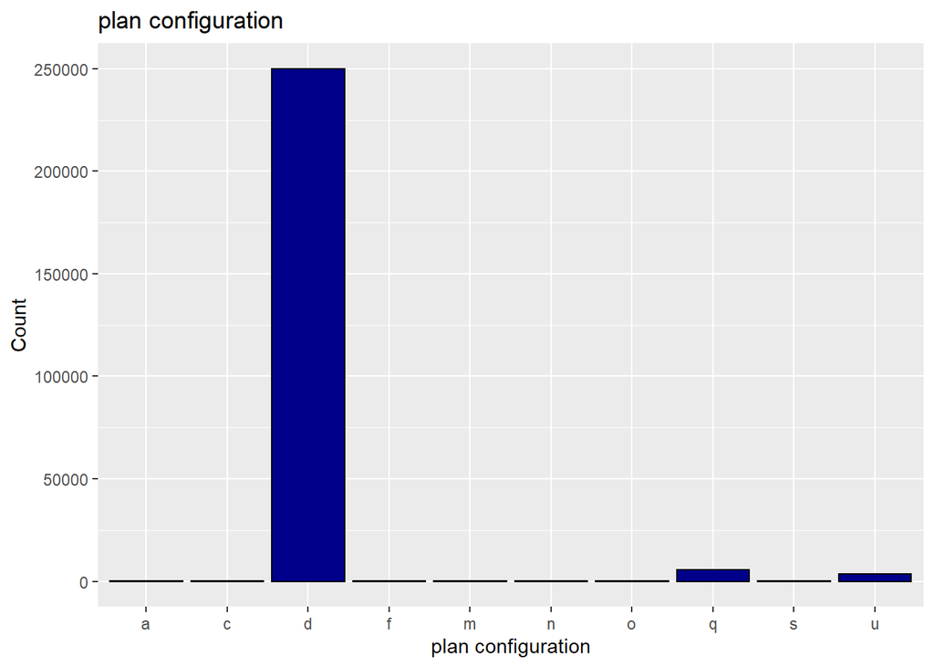

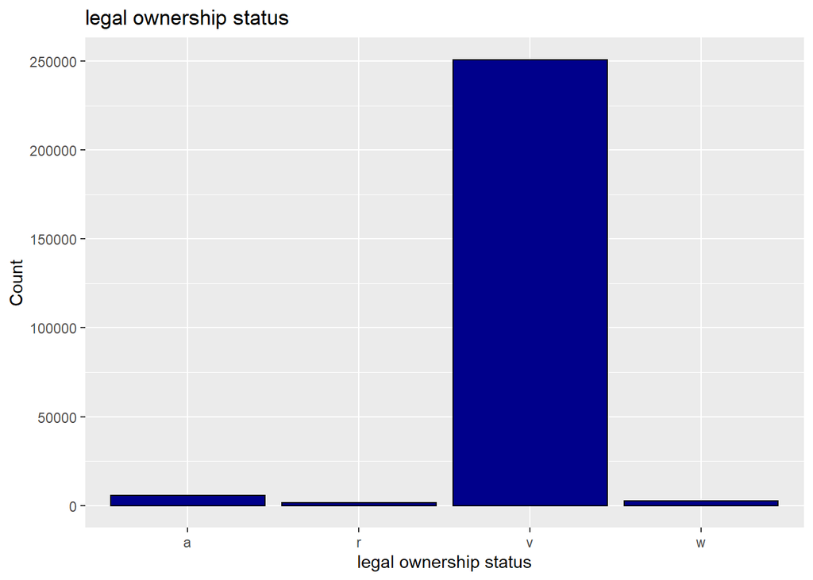

```r
bc1 <- ggplot(data, aes(land_surface_condition)) +
  geom_bar(fill = "darkblue",colour = "black") +
  scale_x_discrete("land surface condition") +
  scale_y_continuous("Count") +
  labs(title = "land surface conditon")

bc2 <- ggplot(data, aes(foundation_type)) +
  geom_bar(fill = "darkblue",colour = "black") +
  scale_x_discrete("foundation type") +
  scale_y_continuous("Count") +
  labs(title = "foundation type")

bc3 <- ggplot(data, aes(roof_type)) +
  geom_bar(fill = "darkblue",colour = "black") +
  scale_x_discrete("roof type") +
  scale_y_continuous("Count") +
  labs(title = "roof type")

bc4 <- ggplot(data, aes(ground_floor_type)) +
  geom_bar(fill = "darkblue",colour = "black") +
  scale_x_discrete("ground floor type") +
  scale_y_continuous("Count") +
  labs(title = "ground floor type")

bc5 <- ggplot(data, aes(other_floor_type)) +
  geom_bar(fill = "darkblue",colour = "black") +
  scale_x_discrete("other floor type") +
  scale_y_continuous("Count") +
  labs(title = "other floor type")

bc6 <- ggplot(data, aes(position)) +
  geom_bar(fill = "darkblue",colour = "black") +
  scale_x_discrete("position") +
  scale_y_continuous("Count") +
  labs(title = "position")

bc7 <- ggplot(data, aes(plan_configuration)) +
  geom_bar(fill = "darkblue",colour = "black") +
  scale_x_discrete("plan configuration") +
  scale_y_continuous("Count") +
  labs(title = "plan configuration")

bc8 <- ggplot(data, aes(legal_ownership_status)) +
  geom_bar(fill = "darkblue",colour = "black") +
  scale_x_discrete("legal ownership status") +
  scale_y_continuous("Count") +
  labs(title = "legal ownership status")

par(mfrow = c(4, 4))

bc1; bc2; bc3; bc4; bc5; bc6; bc7; bc8
```

```r
par(mfrow = c(1, 1))
```

### [Q2] [Q1]에서 선택된 변수들에 대해 1-of-C coding (1-hot encoding) 방식을 통해 명목형(요인형) 변수를 범주의 개수만큼의 이진형(binary) 변수들로 구성되는 dummy variable을 생성하시오.

```r
#str(data)
data_input <- data[,c(-39)]
data_target <- data[,c(39)]

# Max-min으로 normalize
num.vars <- data_input[, sapply(data_input, is.numeric)]
maxs <- apply(num.vars, 2, max)
mins <- apply(num.vars, 2, min)
processed <- as.data.frame(scale(num.vars, center = mins, scale = maxs - mins))
apply(processed, 2, range)
```

```
##      geo_level_1_id geo_level_2_id geo_level_3_id count_floors_pre_eq age
## [1,]              0              0              0                   0   0
## [2,]              1              1              1                   1   1
##      area_percentage height_percentage has_superstructure_adobe_mud
## [1,]               0                 0                            0
## [2,]               1                 1                            1
##      has_superstructure_mud_mortar_stone has_superstructure_stone_flag
## [1,]                                   0                             0
## [2,]                                   1                             1
##      has_superstructure_cement_mortar_stone has_superstructure_mud_mortar_brick
## [1,]                                      0                                   0
## [2,]                                      1                                   1
##      has_superstructure_cement_mortar_brick has_superstructure_timber
## [1,]                                      0                         0
## [2,]                                      1                         1
##      has_superstructure_bamboo has_superstructure_rc_non_engineered
## [1,]                         0                                    0
## [2,]                         1                                    1
##      has_superstructure_rc_engineered has_superstructure_other count_families
## [1,]                                0                        0              0
## [2,]                                1                        1              1
##      has_secondary_use has_secondary_use_agriculture has_secondary_use_hotel
## [1,]                 0                             0                       0
## [2,]                 1                             1                       1
##      has_secondary_use_rental has_secondary_use_institution
## [1,]                        0                             0
## [2,]                        1                             1
##      has_secondary_use_school has_secondary_use_industry
## [1,]                        0                          0
## [2,]                        1                          1
##      has_secondary_use_health_post has_secondary_use_gov_office
## [1,]                             0                            0
## [2,]                             1                            1
##      has_secondary_use_use_police has_secondary_use_other
## [1,]                            0                       0
## [2,]                            1                       1
```

```r
remove(mins, maxs, num.vars)

vars <- data[ , sapply(data, is.factor)]
vars <- colnames(vars)
```

```r
# 팩터를 더미 변수로 변경
for (i in 1:length(vars) ) {
  var <- vars[i]
  new <- dummy.code(data[,var]) # 팩터를 더미 변수로 변경

  # 더미 변수들 이름 변경하기
  new <- dummy.code(data[,var])
  names <- colnames(new)
  names <- paste(var, names, sep = ".")
  colnames(new) <- names
  remove(names)

  processed <- data.frame(processed, new)
  remove(new)
}

processed <- data.frame(processed, data$damage_grade)
remove(i, vars, var)
```

```r
set.seed(100)
dim(processed)
```

```
## [1] 260601     69
```

```r
n_instance <- dim(processed)[1]
n_var <- dim(processed)[2]

indexes <- sample(1:n_instance)
train <- processed[indexes<=150000,]
validation <- processed[150001<=indexes & indexes <= 200000,]
test <- processed[indexes>=200001,]
```

### [Q3] Training 및 Validation 데이터셋을 바탕으로 실습 시간에 사용한 “nnet” package를 사용하여 다음 hyper-parameter 조합들에 대한 Grid search를 수행하여 최적의 조합을 찾아보시오(합계 최소 21가지 이상 탐색). 아래 두 가지 이외의 hyper-parameter는 nnet package의 default value를 사용하시오. 성능이 가장 우수한 조합과 가장 열등한 조합과의 Accuracy와 BCR의 차이는 얼마인가?

- number of hidden node : 2, 3, 4, 5, 6, 7, 8
- maxit: 50, 100, 150

```r
# Initialize performance matrix
perf_summary <- matrix(0, nrow = 2, ncol = 2)
colnames(perf_summary) <- c("ACC", "BCR")
rownames(perf_summary) <- c("best","worst")

# Train ANN
ann_trn_input <- train[,-n_var]
ann_trn_target <- class.ind(train[,n_var])

# Valid the ANN
ann_val_input = validation[,-n_var]
ann_val_target = class.ind(validation[,n_var])

# Find the best number of hidden nodes in terms of BCR
# Candidate hidden nodes
nH <- seq(from=2, to=8, by=1)
nM <- c(50, 100, 150)
val_perf <- matrix(0, 21, 4)
colnames(val_perf) <- c("nH", "nM", "ACC", "BCR")

k = 1

for (i in 1:length(nH)) {
    cat("Training ANN: the number of hidden nodes:", nH[i], "\n")
    for (j in 1:length(nM)) {
        tmp_nnet <- nnet(ann_trn_input, ann_trn_target, size = nH[i],
                         decay = 5e-4, maxit = nM[j])
        prey <- predict(tmp_nnet, ann_val_input)
        cfm <- table(max.col(ann_val_target), factor(max.col(prey),
                                                     levels = (1:3)))
        val_perf[k,1] <- nH[i]
        val_perf[k,2] <- nM[j]
        # Record the validation performance
        val_perf[k,3:4] <- perf_eval_multi(cfm)
        k = k + 1
    }
}

ordered_val_perf <- val_perf[order(val_perf[,3], decreasing = TRUE),]
colnames(ordered_val_perf) <- c("nH", "nM", "ACC", "BCR")
ordered_val_perf
```

[output not shown]

```r
best_nH <- ordered_val_perf[1,1]
best_nM <- ordered_val_perf[1,2]
worst_nH <- ordered_val_perf[nrow(ordered_val_perf),1]
worst_nM <- ordered_val_perf[nrow(ordered_val_perf),2]
# Test the ANN
ann_tst_input = test[,-n_var]
ann_tst_target = class.ind(test[,n_var])

best.nnet <- nnet(ann_trn_input, ann_trn_target, size = best_nH,
                  maxit = best_nM)
worst.nnet <- nnet(ann_trn_input, ann_trn_target, size = worst_nH,
                   maxit = worst_nM)
# Performance evaluation
prey.best <- predict(best.nnet, ann_tst_input)
tst_cm.best <- table(max.col(ann_tst_target), max.col(prey.best))
tst_cm.best

prey.worst <- predict(worst.nnet, ann_tst_input)
tst_cm.worst <- table(max.col(ann_tst_target), max.col(prey.worst))
tst_cm.worst

perf_summary[1,] <- perf_eval_multi(tst_cm.best)
perf_summary[2,] <- perf_eval_multi(tst_cm.worst)

perf_summary
```

[output not shown]

### [Q4] [Q3]에서 선택된 최적의 모델 구조에 nnet의 rang 옵션(default value = 0.7)을 세 가지 이상 변경해가면서 성능 변화를 살펴보시오. [Q3]의 방식과 마찬가지로 Training/Validation 데이터셋을 사용하여 탐색하시오.

[output not shown]

```r
model1.nnet <- nnet(ann_trn_input, ann_trn_target, size = best_nH, range=0.1, maxit = best_nM)
model2.nnet <- nnet(ann_trn_input, ann_trn_target, size = best_nH, range=0.3, maxit = best_nM)
model3.nnet <- nnet(ann_trn_input, ann_trn_target, size = best_nH, range=0.5, maxit = best_nM)

# Performance evaluation
prey.model1 <- predict(model1.nnet, ann_val_input)
valid_cm.model1 <- table(max.col(ann_val_target),
                         factor(max.col(prey.model1), levels = (1:3)))
valid_cm.model1


prey.model2 <- predict(model2.nnet, ann_val_input)
valid_cm.model2 <- table(max.col(ann_val_target),
                         factor(max.col(prey.model2), levels = (1:3)))
valid_cm.model2

prey.model3 <- predict(model3.nnet, ann_val_input)
valid_cm.model3 <- table(max.col(ann_val_target),
                         factor(max.col(prey.model3), levels = (1:3)))
valid_cm.model3

perf_summary2 <- matrix(0, nrow = 3, ncol = 2)
colnames(perf_summary2) <- c("ACC", "BCR")
rownames(perf_summary2) <- c("1","2", "3")

perf_summary2[1,] <- perf_eval_multi(valid_cm.model1)
perf_summary2[2,] <- perf_eval_multi(valid_cm.model2)
perf_summary2[3,] <- perf_eval_multi(valid_cm.model3)
perf_summary2
```

### [Q5] [Q3]에서 확인된 최적의 hidden node의 수와 최적의 maxit, 그리고 [Q4]에서 확인된 가장 우수한 rang option으로 ANN 모델 구조를 확정하고 Training dataset과 Validation dataset을 결합한 데이터셋에 대해 학습을 수행하시오. 학습이 완료된 ANN 모델을 Test dataset에 적용하여 Accuracy와 BCR을 살펴보시오. 동일한 과정을 10회 반복 수행하여 수행 회차에 따라 정확도의 변동성은 어느 정도 되는지 확인하시오.

|  | ACC | BCR |
| --- | --- | --- |
| 1 | 0.6203363 | 0.4713044 |
| 2 | 0.5685385 | 0.0000000 |
| 3 | 0.5685385 | 0.0000000 |
| 4 | 0.5685385 | 0.0000000 |
| 5 | 0.6269864 | 0.5214422 |
| 6 | 0.5685385 | 0.0000000 |
| 7 | 0.6207983 | 0.4883909 |
| 8 | 0.6310127 | 0.4054315 |
| 9 | 0.6170195 | 0.4744880 |
| 10 | 0.6311117 | 0.4743787 |

```r
trn_input <- rbind(ann_trn_input, ann_val_input)
trn_target <- rbind(ann_trn_target,ann_val_target)

perf_summary3 <- matrix(0, nrow = 10, ncol = 2)
colnames(perf_summary3) <- c("ACC", "BCR")
rownames(perf_summary3) <- c("1","2","3","4","5","6","7","8","9","10")

for (i in 1:10) {
  bob.nnet <- nnet(trn_input, trn_target, size = 6, range=0.3, maxit = 150)

  bob.prey <- predict(bob.nnet, ann_tst_input)
  tst_cm.bob <- table(max.col(ann_tst_target),
                           factor(max.col(bob.prey), levels = (1:3)))
  tst_cm.bob
  perf_summary3[i,] <- perf_eval_multi(tst_cm.bob)
}

perf_summary3
```

### [Q6] [Q5]에서 사용된 모델 하이퍼파라미터를 고정시킨 상태에서 Genetic Algorithm을 이용한 변수 선택 모듈을 추가로 작성하여 최적으로 선택된 변수조합 을 확인해 보시오. Genetic Algorithm에서 변경 가능한 옵션의 경우 본인의 Assignment 3에서 설정했던 최적값들을 그대로 사용하시오. Chromosome의 초기값을 다르게 설정하고 변수 선택을 3회 수행한 뒤, 동일한 변수 조합들이 선택 되는지, 아니면 반복 회차마다 다른 변수들이 선택되는지 확인해 보시오.

GA결과 BCR의 값은 변화하지 않았지만 선택된 변수의 조합은 14개가 나왔다. 또한 크로모좀의 초기값을 다르게 설정하고 변수 선택을 수행한 결과, 반복 회차마다 다른 변수들이 선택되는 것을 확인할 수 있었다.

```r
ann_trn_input <- train[,-n_var]
ann_trn_target <- class.ind(train[,n_var])

# Valid the ANN
ann_val_input = validation[,-n_var]
ann_val_target = class.ind(validation[,n_var])

trn_input <- rbind(ann_trn_input, ann_val_input)
trn_target <- rbind(ann_trn_target,ann_val_target)

bob.nnet <- nnet(trn_input, trn_target, size = 6, range=0.3, maxit = 150)
fit_bcr <- function(string){
  sel_var_idx <- which(string == 1)
  # Use variables whose gene value is 1
  sel_x <- trn_input[, sel_var_idx]
  xy <- data.frame(sel_x, trn_target)
  # Training the model
  GA_lr <- bob.nnet
  GA_lr_prob <- predict(GA_lr, trn_input)
  GA_lr_cm <- table(max.col(trn_target),
                           factor(max.col(GA_lr_prob), levels = (1:3)))
  GA_perf <- perf_eval_multi(GA_lr_cm)
  return(GA_perf[2])
  }

GA_BCR1 <- ga(type = "binary", fitness = fit_bcr, nBits = ncol(trn_input),
            names = colnames(trn_input), popSize = 50, pcrossover = 0.5,
            pmutation = 0.01, maxiter = 20, elitism = 2, seed = 100)
GA_BCR2 <- ga(type = "binary", fitness = fit_bcr, nBits = ncol(trn_input),
            names = colnames(trn_input), popSize = 30, pcrossover = 0.5,
            pmutation = 0.01, maxiter = 20, elitism = 2, seed = 100)
GA_BCR3 <- ga(type = "binary", fitness = fit_bcr, nBits = ncol(trn_input),
            names = colnames(trn_input), popSize = 10, pcrossover = 0.5,
            pmutation = 0.01, maxiter = 20, elitism = 2, seed = 100)

GA_BCR1@solution
```

```
##       geo_level_1_id geo_level_2_id geo_level_3_id count_floors_pre_eq age
##  [1,]              0              0              1                   0   0
##  [2,]              1              1              1                   0   1
##  [3,]              1              1              1                   1   0
##  [4,]              1              1              1                   0   1
##  [5,]              0              1              1                   0   1
##  [6,]              0              1              1                   0   1
##  [7,]              0              0              1                   0   1
##  [8,]              1              0              0                   0   0
##  [9,]              1              0              0                   0   0
## [10,]              1              0              0                   0   0
## [11,]              0              0              1                   0   1
## [12,]              0              1              1                   0   1
## [13,]              0              1              1                   0   1
## [14,]              1              1              1                   0   0
```

[output cut: 1110 more lines]

```r
GA_BCR2@solution
```

```
##       geo_level_1_id geo_level_2_id geo_level_3_id count_floors_pre_eq age
##  [1,]              0              1              1                   0   0
##  [2,]              1              0              0                   1   0
##  [3,]              0              1              1                   0   0
##  [4,]              0              1              1                   0   0
##  [5,]              0              1              0                   0   0
##  [6,]              0              1              0                   0   0
##  [7,]              0              1              1                   0   0
##  [8,]              0              1              0                   0   0
##  [9,]              0              1              1                   0   0
## [10,]              0              1              1                   0   0
## [11,]              0              1              0                   0   0
## [12,]              0              1              0                   0   0
## [13,]              0              1              1                   0   0
## [14,]              0              1              1                   0   0
```

[output cut: 560 more lines]

```r
GA_BCR3@solution
```

```
##      geo_level_1_id geo_level_2_id geo_level_3_id count_floors_pre_eq age
## [1,]              1              1              0                   1   0
## [2,]              1              1              0                   1   0
##      area_percentage height_percentage has_superstructure_adobe_mud
## [1,]               1                 0                            0
## [2,]               1                 0                            0
##      has_superstructure_mud_mortar_stone has_superstructure_stone_flag
## [1,]                                   0                             0
## [2,]                                   0                             0
##      has_superstructure_cement_mortar_stone has_superstructure_mud_mortar_brick
## [1,]                                      1                                   0
## [2,]                                      1                                   0
##      has_superstructure_cement_mortar_brick has_superstructure_timber
## [1,]                                      1                         1
## [2,]                                      1                         1
##      has_superstructure_bamboo has_superstructure_rc_non_engineered
## [1,]                         1                                    0
## [2,]                         1                                    0
##      has_superstructure_rc_engineered has_superstructure_other count_families
## [1,]                                0                        0              1
## [2,]                                0                        0              1
##      has_secondary_use has_secondary_use_agriculture has_secondary_use_hotel
## [1,]                 1                             1                       0
## [2,]                 1                             1                       0
##      has_secondary_use_rental has_secondary_use_institution
## [1,]                        1                             1
## [2,]                        1                             1
##      has_secondary_use_school has_secondary_use_industry
## [1,]                        1                          1
## [2,]                        1                          1
##      has_secondary_use_health_post has_secondary_use_gov_office
## [1,]                             1                            0
## [2,]                             1                            0
##      has_secondary_use_use_police has_secondary_use_other
## [1,]                            1                       1
## [2,]                            1                       1
##      land_surface_condition.t land_surface_condition.n land_surface_condition.o
## [1,]                        1                        0                        0
## [2,]                        1                        0                        0
##      foundation_type.r foundation_type.w foundation_type.u foundation_type.i
```

[output cut: 14 more lines]

```
##      position.o plan_configuration.d plan_configuration.q plan_configuration.u
## [1,]          0                    1                    0                    1
## [2,]          0                    1                    1                    1
##      plan_configuration.s plan_configuration.c plan_configuration.a
## [1,]                    0                    1                    0
## [2,]                    0                    1                    0
##      plan_configuration.o plan_configuration.m plan_configuration.n
## [1,]                    0                    0                    0
## [2,]                    0                    0                    0
##      plan_configuration.f legal_ownership_status.v legal_ownership_status.a
## [1,]                    0                        1                        0
## [2,]                    0                        1                        0
##      legal_ownership_status.w legal_ownership_status.r
## [1,]                        1                        1
## [2,]                        1                        1
```

```r
best_var_idx1 <- which(GA_BCR1@solution[14,]==1)
best_var_idx2 <- which(GA_BCR2@solution[14,]==1)
best_var_idx3 <- which(GA_BCR3@solution[2,]==1)
```

### [Q7] [Q6]에서 GA를 통해 한 번 이상 주요 변수로 선택된 모든 변수들을 사용 하여 나머지 설정은 [Q5]와 동일하게 하여 Test dataset에 대한 Accuracy와 BCR을 확인하고 모든 변수를 사용한 모델인 [Q5]의 결과와 비교해 보시오.

```r
best_var_idx <- unique(best_var_idx1, best_var_idx2, best_var_idx3)
GA_trn_input <- trn_input[,c(best_var_idx)]
GA_tst_input <- ann_tst_input[,c(best_var_idx)]

GA_model <- nnet(GA_trn_input, trn_target, size = 6, range=0.3, maxit = 150)

GA.prey <- predict(GA_model, ann_tst_input)
GA_cm <- table(max.col(ann_tst_target),
                       factor(max.col(GA.prey), levels = (1:3)))
GA_cm
perf_eval_multi(GA_cm)
```

### [Q8] 동일한 Training/Validation 데이터셋을 이용하여 최적의 의사결정나무 하이퍼파라미터 조합을 탐색해 보시오. 이후 최적의 하이퍼파라미터 조합을 이용하여 Training/Validation 데이터셋을 결합한 데이터셋으로 의사결정나무를 학습 한 뒤, Test Dataset에 대한 Accuracy와 BCR을 산출해 보시오.

하이퍼 파라미터들의 후보는 다음과 같이 설정하였다.

min_criterion : 0.8,0.9, 0.95  
min_split : 5, 10, 15  
max_depth : 3, 5, 7, 9

```r
perf_eval <- function(cm){

  # True positive rate: TPR (Recall)
  TPR <- cm[2,2]/sum(cm[2,])
  # Precision
  PRE <- cm[2,2]/sum(cm[,2])
  # True negative rate: TNR
  TNR <- cm[1,1]/sum(cm[1,])
  # Simple Accuracy
  ACC <- (cm[1,1]+cm[2,2])/sum(cm)
  # Balanced Correction Rate
  BCR <- sqrt(TPR*TNR)
  # F1-Measure
  F1 <- 2*TPR*PRE/(TPR+PRE)

  return(c(TPR, PRE, TNR, ACC, BCR, F1))
}

# Performance table
Perf_Table <- matrix(0, nrow = 2, ncol = 6)
rownames(Perf_Table) <- c("Post-Pruning", "Pre-Pruning")
colnames(Perf_Table) <- c("TPR", "Precision", "TNR", "Accuracy",
                          "BCR", "F1-Measure")
```

```r
min_criterion = c(0.8, 0.9, 0.95)
min_split = c(5, 10, 15)
max_depth = c(3, 5, 7, 9)
CART_pre_search_result = matrix(0,length(min_criterion)*length(min_split)*length(max_depth),10)
colnames(CART_pre_search_result) <- c("min_criterion", "min_split",
                                      "max_depth", "TPR", "Precision", "TNR",
                                      "ACC", "BCR", "F1", "N_leaves")
iter_cnt = 1


for (i in 1:length(min_criterion)){
  for ( j in 1:length(min_split)){
    for ( k in 1:length(max_depth)){

      cat("CART Min criterion:", min_criterion[i], ", Min split:", min_split[j], ", Max depth:", max_depth[k], "\n")
      tmp_control = ctree_control(mincriterion = min_criterion[i], minsplit = min_split[j], maxdepth = max_depth[k])
      tmp_tree <- ctree(data.damage_grade ~ ., data = train,
                        controls = tmp_control)
      tmp_tree_val_prediction <- predict(tmp_tree, newdata = validation)
      tmp_tree_val_response <- treeresponse(tmp_tree, newdata = validation)
      tmp_tree_val_prob <- 1-unlist(tmp_tree_val_response, use.names=F)[seq(1,nrow(validation)*2,2)]
      #tmp_tree_val_rocr <- prediction(tmp_tree_val_prob,
                                      #validation$data.damage_grade)
      # Confusion matrix for the validation dataset
      tmp_tree_val_cm <- table(validation$data.damage_grade,
                               tmp_tree_val_prediction)

      # parameters
      CART_pre_search_result[iter_cnt,1] = min_criterion[i]
      CART_pre_search_result[iter_cnt,2] = min_split[j]
      CART_pre_search_result[iter_cnt,3] = max_depth[k]
      # Performances from the confusion matrix
      CART_pre_search_result[iter_cnt,4:9] = perf_eval(tmp_tree_val_cm)
      # Number of leaf nodes
      CART_pre_search_result[iter_cnt,10] = length(nodes(tmp_tree, unique(where(tmp_tree))))
      iter_cnt = iter_cnt + 1
    }
  }
}

# Find the best set of parameters
CART_pre_search_result <- CART_pre_search_result[order(CART_pre_search_result[,10], decreasing = T),]
CART_pre_search_result
best_criterion <- CART_pre_search_result[1,1]
best_split <- CART_pre_search_result[1,2]
best_depth <- CART_pre_search_result[1,3]

tree_control = ctree_control(mincriterion = best_criterion, minsplit = best_split, maxdepth = best_depth)

CART_trn <- rbind(train, validation)
CART_best <- ctree(data.damage_grade ~ ., data = CART_trn, controls = tree_control)
plot(CART_best)

CART_pre <- ctree(data.damage_grade ~ ., data = CART_trn, controls = tree_control)
CART_pre_prediction <- predict(CART_pre, newdata = test)
CART_pre_prediction <- ifelse(CART_pre_response > 2.5, 3, ifelse(CART_pre_response > 1.5, 2, 1))
# Performance of the best tree
CART_pre_cm <- table(test$data.damage_grade , CART_pre_prediction)
CART_pre_cm

Perf_Table <- perf_eval(CART_pre_cm)
Perf_Table
```

### [Q9] Training dataset과 Validation dataset을 결합하여 Multinomial logistic regression을 학습하고, 이를 Test dataset에 적용하여 Accuracy와 BCR을 산출하고 이를 [Q5], [Q7], [Q8]의 결과와 비교해 보시오. (Hint: 아래와 같은 표를 작성해 보시오)

```r
MLR_trn <- CART_trn
MLR_tst <- test
MLR_trn$data.damage_grade <- as.factor(MLR_trn$data.damage_grade)
MLR_tst$data.damage_grade <- as.factor(MLR_tst$data.damage_grade)
MLR_model <- multinom(data.damage_grade ~., data = MLR_trn )
summary(MLR_model)

MLR_prey <- predict(MLR_model ,newdata = MLR_tst)
MLR_cm <- table(MLR_tst$data.damage_grade, MLR_prey)
MLR_cm

Perf_Table2 <- perf_eval(MLR_cm)
Perf_Table2
```

| Test Performance | NN(all) | NN(by GA) | DT | MLR |
| --- | --- | --- | --- | --- |
| ACC | 0.6203 | 0.5561 | 0.5303 | 0.5252 |
| BCR | 0.4713 | 0.2525 | 0.5048 | 0.5071 |